# Final Project

Team 1

# Question 1: How well can we predict IMDb movies using main genre, votes, release year, runtime, and certificate?

For the first part of the project, we wanted to see how well we can predict IMDb movie ratings using a few basic features. Specifically, we focused on genre, number of votes, release year, runtime, and certificate rating. The main goal here was not just to build a predictive model, but to understand whether these commonly available features can meaningfully explain variation in movie ratings.

```r
#Importing Necessary Libraries
library(ezids)
library(ggplot2)

#Importing each .csv as data frames, grouped by genre
action = read.csv("action.csv")
adventure = read.csv("adventure.csv")
animation = read.csv("animation.csv")
biography = read.csv("biography.csv")
crime = read.csv("crime.csv")
family = read.csv("family.csv")
fantasy = read.csv("fantasy.csv")
noir = read.csv("film-noir.csv")
history = read.csv("history.csv")
horror = read.csv("horror.csv")
mystery = read.csv("mystery.csv")
romance = read.csv("romance.csv")
scifi = read.csv("scifi.csv")
sports = read.csv("sports.csv")
thriller = read.csv("thriller.csv")
war = read.csv("war.csv")
```

```r
#Checking structure of the data frames (all should be the same as action)
str(action)
```

```
## 'data.frame':    52452 obs. of  14 variables:
##  $ movie_id   : chr  "tt9114286" "tt1630029" "tt5884796" "tt6710474" ...
##  $ movie_name : chr  "Black Panther: Wakanda Forever" "Avatar: The Way of Water" "Plane" "Everything Everywhere All at Once" ...
##  $ year       : chr  "2022" "2022" "2023" "2022" ...
##  $ certificate: chr  "PG-13" "PG-13" "R" "R" ...
##  $ runtime    : chr  "161 min" "192 min" "107 min" "139 min" ...
##  $ genre      : chr  "Action, Adventure, Drama" "Action, Adventure, Fantasy" "Action, Thriller" "Action, Adventure, Comedy" ...
##  $ rating     : num  6.9 7.8 6.5 8 NA 6.6 5.4 7.3 7.8 8.3 ...
##  $ description: chr  "The people of Wakanda fight to protect their home from intervening world powers as they mourn the death of King T'Challa." "Jake Sully lives with his newfound family formed on the extrasolar moon Pandora. Once a familiar threat returns"| __truncated__ "A pilot finds himself …
##  $ director   : chr  "Ryan Coogler" "James Cameron" "Jean-François Richet" "Dan Kwan, \nDaniel Scheinert" ...
##  $ director_id: chr  "/name/nm3363032/" "/name/nm0000116/" "/name/nm0724938/" "/name/nm3453283/" ...
##  $ star       : chr  "Letitia Wright, \nLupita Nyong'o, \nDanai Gurira, \nWinston Duke" "Sam Worthington, \nZoe Saldana, \nSigourney Weaver, \nStephen Lang" "Gerard Butler, \nMike Colter, \nTony Goldwyn, \nYoson An" "Michelle Yeoh, \nStephanie Hsu, \nJamie Lee Curtis, \nKe Huy Quan" ...
##  $ star_id    : chr  "/name/nm4004793/,/name/nm2143282/,/name/nm1775091/,/name/nm6328300/" "/name/nm0941777/,/name/nm0757855/,/name/nm0000244/,/name/nm0002332/" "/name/nm0124930/,/name/nm1591496/,/name/nm0001282/,/name/nm5256788/" "/name/nm3215397/,/name/nm0000706/,/name/nm3513533/,/name/nm000013…
##  $ votes      : num  204835 295119 26220 327858 NA ...
##  $ gross.in...: num  NA NA NA NA NA NA NA NA NA NA ...
```

```r
#We can remove some columns as we will not be needing them (some others are left in as we could use possibly ask more questions about them later)
action = subset(action, select = -c(description, director, director_id, star, star_id, gross.in...))

#Showing the new structire of the data frame
str(action)
```

```
## 'data.frame':    52452 obs. of  8 variables:
##  $ movie_id   : chr  "tt9114286" "tt1630029" "tt5884796" "tt6710474" ...
##  $ movie_name : chr  "Black Panther: Wakanda Forever" "Avatar: The Way of Water" "Plane" "Everything Everywhere All at Once" ...
##  $ year       : chr  "2022" "2022" "2023" "2022" ...
##  $ certificate: chr  "PG-13" "PG-13" "R" "R" ...
##  $ runtime    : chr  "161 min" "192 min" "107 min" "139 min" ...
##  $ genre      : chr  "Action, Adventure, Drama" "Action, Adventure, Fantasy" "Action, Thriller" "Action, Adventure, Comedy" ...
##  $ rating     : num  6.9 7.8 6.5 8 NA 6.6 5.4 7.3 7.8 8.3 ...
##  $ votes      : num  204835 295119 26220 327858 NA ...
```

```r
#Removing the columns for the rest of the data frames
adventure = subset(adventure, select = -c(description, director, director_id, star, star_id, gross.in...))

animation = subset(animation, select = -c(description, director, director_id, star, star_id, gross.in...))

biography = subset(biography, select = -c(description, director, director_id, star, star_id, gross.in...))

crime = subset(crime, select = -c(description, director, director_id, star, star_id, gross.in...))

family = subset(family, select = -c(description, director, director_id, star, star_id, gross.in...))

fantasy = subset(fantasy, select = -c(description, director, director_id, star, star_id, gross.in...))

noir = subset(noir, select = -c(description, director, director_id, star, star_id, gross.in...))

history = subset(history, select = -c(description, director, director_id, star, star_id, gross.in...))

horror = subset(horror, select = -c(description, director, director_id, star, star_id, gross.in...))

mystery = subset(mystery, select = -c(description, director, director_id, star, star_id, gross.in...))

romance = subset(romance, select = -c(description, director, director_id, star, star_id, gross.in...))

scifi = subset(scifi, select = -c(description, director, director_id, star, star_id, gross.in...))

sports = subset(sports, select = -c(description, director, director_id, star, star_id, gross.in...))

thriller = subset(thriller, select = -c(description, director, director_id, star, star_id, gross.in...))

war = subset(war, select = -c(description, director, director_id, star, star_id, gross.in...))
```

```r
#Combining all the data frames and removing duplicates, we can still use the data frames above for analysis, however.  Both methods are valid depending on our questions and eda.
allmovies = rbind(action, adventure, animation, biography, crime, family, fantasy, noir, history, horror, mystery, romance, scifi, sports, thriller, war)

#Remove duplicates
allmovies <- allmovies[!duplicated(allmovies$movie_id), ]

#Check for duplicates
duplicates = sum(duplicated(allmovies))
duplicates
```

```
## [1] 0
```

```r
allmovies$year <- as.numeric(allmovies$year)
str(allmovies)
```

```
## 'data.frame':    243197 obs. of  8 variables:
##  $ movie_id   : chr  "tt9114286" "tt1630029" "tt5884796" "tt6710474" ...
##  $ movie_name : chr  "Black Panther: Wakanda Forever" "Avatar: The Way of Water" "Plane" "Everything Everywhere All at Once" ...
##  $ year       : num  2022 2022 2023 2022 2023 ...
##  $ certificate: chr  "PG-13" "PG-13" "R" "R" ...
##  $ runtime    : chr  "161 min" "192 min" "107 min" "139 min" ...
##  $ genre      : chr  "Action, Adventure, Drama" "Action, Adventure, Fantasy" "Action, Thriller" "Action, Adventure, Comedy" ...
##  $ rating     : num  6.9 7.8 6.5 8 NA 6.6 5.4 7.3 7.8 8.3 ...
##  $ votes      : num  204835 295119 26220 327858 NA ...
```

```r
# For Q1, we prepared a cleaned dataset using variables relevant to rating prediction.
# We kept movies released between 2000 and 2023 and removed rows with missing values.

allmovies$year_num <- as.numeric(allmovies$year)
allmovies$runtime_num <- as.numeric(sub(" min", "", allmovies$runtime))

q1data <- subset(allmovies,
  !is.na(rating) &
  !is.na(votes) &
  !is.na(year_num) &
  !is.na(runtime_num) &
  !is.na(certificate) &
  year_num >= 2000 &
  year_num <= 2023
)

q1data$main_genre <- sub(",.*", "", q1data$genre)
q1data$main_genre <- as.factor(trimws(q1data$main_genre))
q1data$certificate <- as.factor(q1data$certificate)

str(q1data)
```

```
## 'data.frame':    68902 obs. of  11 variables:
##  $ movie_id   : chr  "tt9114286" "tt1630029" "tt5884796" "tt6710474" ...
##  $ movie_name : chr  "Black Panther: Wakanda Forever" "Avatar: The Way of Water" "Plane" "Everything Everywhere All at Once" ...
##  $ year       : num  2022 2022 2023 2022 2023 ...
##  $ certificate: Factor w/ 38 levels "","12","13","13+",..: 22 22 23 23 22 23 23 23 22 19 ...
##  $ runtime    : chr  "161 min" "192 min" "107 min" "139 min" ...
##  $ genre      : chr  "Action, Adventure, Drama" "Action, Adventure, Fantasy" "Action, Thriller" "Action, Adventure, Comedy" ...
##  $ rating     : num  6.9 7.8 6.5 8 6.6 5.4 7.3 7.8 8.3 6.6 ...
##  $ votes      : num  204835 295119 26220 327858 5396 ...
##  $ year_num   : num  2022 2022 2023 2022 2023 ...
##  $ runtime_num: num  161 192 107 139 125 100 127 148 130 146 ...
##  $ main_genre : Factor w/ 22 levels "Action","Adult",..: 1 1 1 1 1 1 1 1 1 1 ...
```

```r
summary(q1data)
```

```
##    movie_id          movie_name             year         certificate
##  Length:68902       Length:68902       Min.   :2000            :42179
##  Class :character   Class :character   1st Qu.:2009   Not Rated:10387
##  Mode  :character   Mode  :character   Median :2014   R        : 6917
##                                        Mean   :2013   PG-13    : 2889
##                                        3rd Qu.:2018   PG       : 1499
##                                        Max.   :2023   TV-MA    : 1451
##                                                       (Other)  : 3580
##    runtime             genre               rating          votes
##  Length:68902       Length:68902       Min.   : 1.00   Min.   :      5
##  Class :character   Class :character   1st Qu.: 4.80   1st Qu.:     41
##  Mode  :character   Mode  :character   Median : 5.80   Median :    200
##                                        Mean   : 5.73   Mean   :   9252
##                                        3rd Qu.: 6.70   3rd Qu.:   1144
##                                        Max.   :10.00   Max.   :2675531
##
##     year_num     runtime_num        main_genre
##  Min.   :2000   Min.   :  1.0   Drama    :14020
##  1st Qu.:2009   1st Qu.: 86.0   Action   :12773
##  Median :2014   Median : 95.0   Comedy   :12323
##  Mean   :2013   Mean   : 98.9   Horror   : 7843
##  3rd Qu.:2018   3rd Qu.:109.0   Crime    : 5091
##  Max.   :2023   Max.   :999.0   Animation: 3346
##                                 (Other)  :13506
```

The dataset originally consisted of multiple files separated by genre, so first combined them into a single dataset. I combined all of these into a single dataset and removed duplicate entries based on movie IDs to ensure that each movie appeared only once. Then, removed unnecessary variables like description, director information, and gross revenue.

Next, I cleaned and formatted the data. The release year and runtime were converted into numeric variables, and I filtered the dataset to include only movies released between 2000 and 2023. Observations with missing values in key variables like ratings, votes, runtime, and certificate were removed.

Since movies can have multiple genres, I created a “main genre” variable by extracting the first listed genre. Certificate ratings were also converted into categorical variables.

```r
# The number of votes is highly skewed, so we apply a log transformation.
q1data$log_votes <- log(q1data$votes + 1)

# Remove unrealistic runtime outliers
q1data <- subset(q1data, runtime_num >= 40 & runtime_num <= 240)

summary(q1data$log_votes)
```

```
##    Min. 1st Qu.  Median    Mean 3rd Qu.    Max.
##    1.79    3.74    5.30    5.62    7.04   14.80
```

```r
summary(q1data$runtime_num)
```

```
##    Min. 1st Qu.  Median    Mean 3rd Qu.    Max.
##    40.0    86.0    95.0    98.7   109.0   240.0
```

Because the number of votes was highly skewed, I applied a log transformation. Then removed extreme runtime values to avoid the influence of outliers.

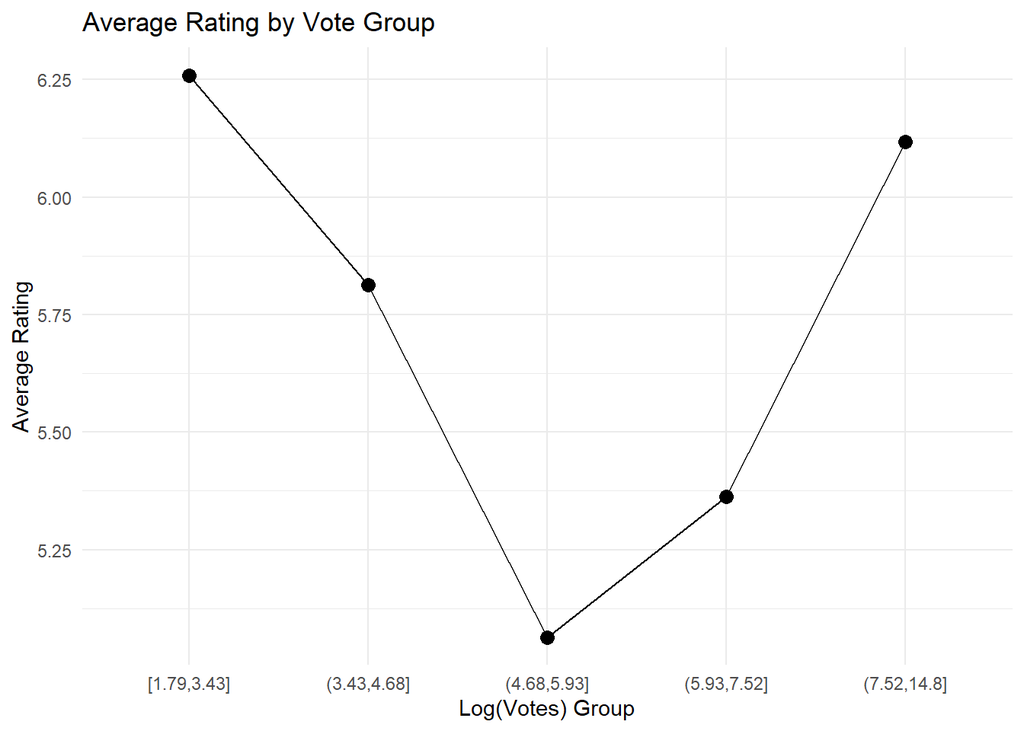

```r
# Create vote groups based on quintiles of log-transformed votes
q1data$vote_group <- cut(
  q1data$log_votes,
  breaks = quantile(q1data$log_votes, probs = seq(0, 1, 0.2), na.rm = TRUE),
  include.lowest = TRUE
)

# Calculate average rating by vote group
vote_summary <- aggregate(rating ~ vote_group, data = q1data, mean)

ggplot(vote_summary, aes(x = vote_group, y = rating, group = 1)) +
  geom_point(size = 3) +
  geom_line() +
  labs(title = "Average Rating by Vote Group",
       x = "Log(Votes) Group",
       y = "Average Rating") +
  theme_minimal()
```

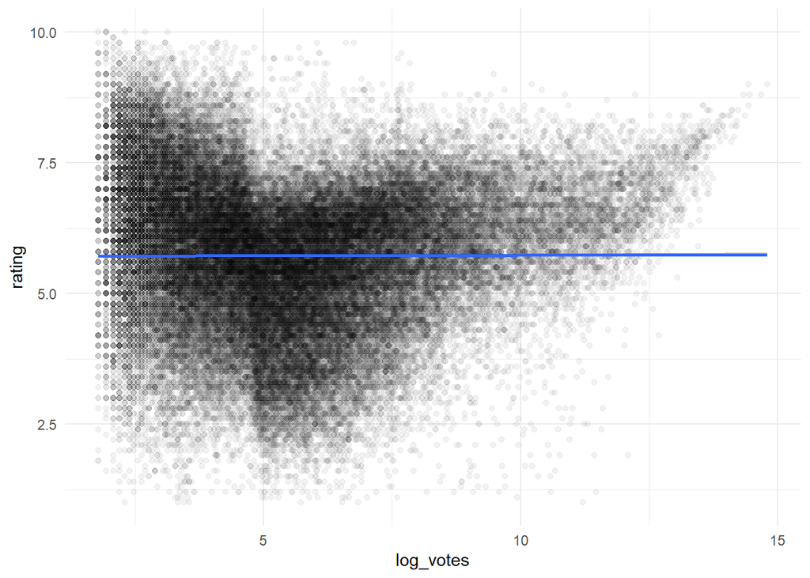

```r
ggsave("average_rating_by_vote_group.png", width = 8, height = 6)

ggplot(q1data, aes(x = log_votes, y = rating)) +
  geom_point(alpha = 0.05) +
  geom_smooth(method = "lm") +
  theme_minimal()
```

To better understand this pattern, I grouped movies into categories based on vote levels and calculated the average rating for each group. Based on the result, the relationship is not strictly linear. Movies with very low vote counts tend to have relatively high average ratings, while movies in the mid-range vote groups show noticeably lower ratings. As the number of votes increase further, the average rating rises again. This created a U-shaped pattern rather than a simple increasing trend. Overall, this indicates that the relationship between votes and ratings is more complex than a simple positive correlation.

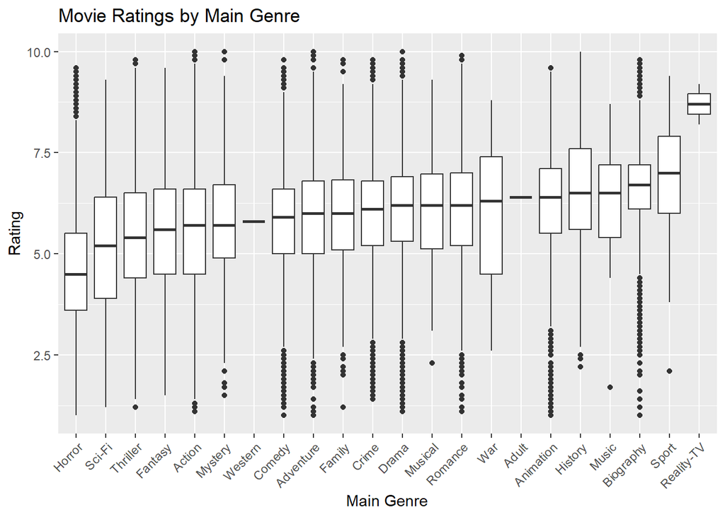

```r
ggplot(q1data, aes(x = reorder(main_genre, rating, median), y = rating)) +
  geom_boxplot() +
  labs(title = "Movie Ratings by Main Genre",
       x = "Main Genre",
       y = "Rating") +
  theme(axis.text.x = element_text(angle = 45, hjust = 1))
```

```r
  stat_summary(fun = median, geom = "point", color = "red", size = 2)
```

```
## geom_point: na.rm = FALSE
## stat_summary: fun.data = NULL, fun = function (x, na.rm = FALSE, ...)
## UseMethod("median"), fun.max = NULL, fun.min = NULL, fun.args = list(), na.rm = FALSE, orientation = NA
## position_identity
```

```r
  theme_minimal() +
  theme(axis.text.x = element_text(angle = 45, hjust = 1))
```

[output not shown]

[output cut: 313 more lines]

[output not shown]

```r
ggsave("ratings_by_main_genre.png", width = 10, height = 6)
```

Next, I tested how movie ratings vary across different genres using a boxplot. The plot shows that there are differences in median ratings across genres, but the differences are not extreme. Genres like biography, history, and reality-TV tend to have higher median ratings, while genres like horror and sci-fi generally have lower median ratings. Based on this result, genre does play a role in explaining ratings, but it is not a dominant factor.

```r
# Compare several linear regression models for Q1
m1 <- lm(rating ~ main_genre + log_votes + year_num, data = q1data)
m2 <- lm(rating ~ main_genre + log_votes + year_num + runtime_num, data = q1data)
m3 <- lm(rating ~ main_genre + log_votes + year_num + runtime_num + certificate, data = q1data)

summary(m1)$r.squared
```

```
## [1] 0.104
```

```r
summary(m2)$r.squared
```

```
## [1] 0.122
```

```r
summary(m3)$r.squared
```

```
## [1] 0.133
```

```r
# Final model for Q1
model_final <- m3
summary(model_final)
```

```
##
## Call:
## lm(formula = rating ~ main_genre + log_votes + year_num + runtime_num +
##     certificate, data = q1data)
##
## Residuals:
##    Min     1Q Median     3Q    Max
## -5.664 -0.842  0.067  0.868  4.977
##
## Coefficients:
##                       Estimate Std. Error t value Pr(>|t|)
## (Intercept)           6.632582   1.770839    3.75  0.00018 ***
## main_genreAdult       1.177011   1.344001    0.88  0.38117
## main_genreAdventure   0.377759   0.026960   14.01  < 2e-16 ***
## main_genreAnimation   0.851397   0.027656   30.79  < 2e-16 ***
## main_genreBiography   0.997256   0.031550   31.61  < 2e-16 ***
## main_genreComedy      0.284497   0.017166   16.57  < 2e-16 ***
## main_genreCrime       0.468398   0.022401   20.91  < 2e-16 ***
## main_genreDrama       0.503180   0.016598   30.32  < 2e-16 ***
## main_genreFamily      0.462639   0.045037   10.27  < 2e-16 ***
## main_genreFantasy     0.088583   0.048443    1.83  0.06746 .
## main_genreHistory     0.874423   0.093006    9.40  < 2e-16 ***
## main_genreHorror     -0.769340   0.019890  -38.68  < 2e-16 ***
## main_genreMusic       0.881174   0.269076    3.27  0.00106 **
## main_genreMusical     0.393716   0.156786    2.51  0.01204 *
## main_genreMystery     0.257118   0.050157    5.13  3.0e-07 ***
## main_genreReality-TV  3.314455   0.950368    3.49  0.00049 ***
## main_genreRomance     0.413888   0.036912   11.21  < 2e-16 ***
## main_genreSci-Fi     -0.272566   0.054181   -5.03  4.9e-07 ***
## main_genreSport       1.306746   0.121903   10.72  < 2e-16 ***
## main_genreThriller    0.024646   0.027925    0.88  0.37747
## main_genreWar         0.421946   0.137082    3.08  0.00208 **
## main_genreWestern    -0.036749   1.343946   -0.03  0.97819
## log_votes            -0.006689   0.002854   -2.34  0.01909 *
## year_num             -0.000927   0.000879   -1.05  0.29167
## runtime_num           0.009064   0.000255   35.52  < 2e-16 ***
## certificate12        -0.959244   1.343911   -0.71  0.47537
## certificate13         0.489232   1.343982    0.36  0.71585
## certificate13+        0.763748   0.672025    1.14  0.25576
## certificate16+       -0.005627   0.405304   -0.01  0.98892
```

[output cut: 24 more lines]

```
## certificateTV-Y      -0.278889   0.231287   -1.21  0.22789
## certificateTV-Y7     -0.407878   0.159492   -2.56  0.01055 *
## certificateTV-Y7-FV   0.371043   0.549209    0.68  0.49930
## certificateU         -0.028438   0.204451   -0.14  0.88938
## certificateUA         0.247453   0.300885    0.82  0.41084
## certificateUA 13+     0.984228   0.950405    1.04  0.30040
## certificateUA 16+     1.445298   0.950409    1.52  0.12834
## certificateUnrated   -0.327730   0.039447   -8.31  < 2e-16 ***
## certificateX         -0.765528   0.672025   -1.14  0.25465
## ---
## Signif. codes:  0 '***' 0.001 '**' 0.01 '*' 0.05 '.' 0.1 ' ' 1
##
## Residual standard error: 1.34 on 68776 degrees of freedom
## Multiple R-squared:  0.133,  Adjusted R-squared:  0.133
## F-statistic:  174 on 61 and 68776 DF,  p-value: <2e-16
```

Model Development: To quantify these relationships, I built three linear regression models. The first model included the main genre, log-transformed votes, and release year. The second model added runtime, and the third model included certificate ratings as well. Each additional variable slightly improved the model. The R-squared increased from about 10.4% in the base model to approximately 13.3% in the final model. Overall explanatory power remains low while showing some improvement.

Model Interpretation: In the final model, several predictors were statistically significant, but their practical influence is limited. Genres like animation, biography, and drama were associated with higher ratings. Genres like horror and sci-fi were associated with lower ratings. However, as it is observed in the EDA, there is substantial overlap across genres, which limits their predictive strength.

Runtime showed a slight positive relationship with ratings, which indicates that longer movies tend to have higher ratings on average. And lastly, certificate ratings also showed some differences. Overall, even though these predictors are statistically significant, none of them strongly predict movie ratings.

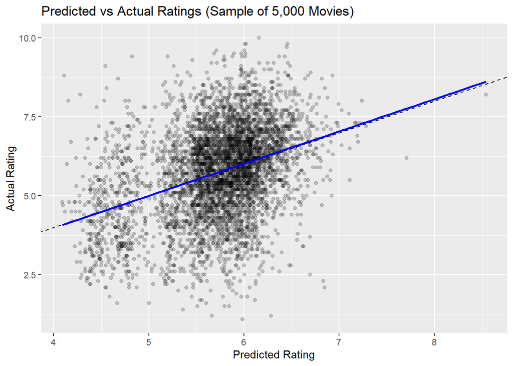

```r
# Create predicted ratings from the final linear regression model
q1data$pred_rating <- predict(model_final)

# Create a random sample for cleaner scatterplots
set.seed(123)
sample_q1 <- q1data[sample(nrow(q1data), 5000), ]

ggplot(sample_q1, aes(x = pred_rating, y = rating)) +
  geom_point(alpha = 0.2) +
  geom_abline(slope = 1, intercept = 0, linetype = "dashed") +
  labs(title = "Predicted vs Actual Ratings (Sample of 5,000 Movies)",
       x = "Predicted Rating",
       y = "Actual Rating") +
  geom_smooth(method = "lm", color = "blue", se = FALSE)
```

```r
  theme_minimal()
```

[output not shown]

[output cut: 313 more lines]

[output not shown]

```r
ggsave("predicted_vs_actual_sample.png", width = 8, height = 6)
```

The predicted vs actual plot showed a clear positive trend, which indicates that the model is able to capture general patterns in the data. But, the points are widely scattered around the diagonal line, meaning the substantial prediction error. A lot of movies with similar predicted ratings have very different actual ratings. This pattern can indicate that the model is able to identify overall trends, but lacks the precision needed for accurate prediction at the individual movie level.

Conclusion: Overall, the model provides some insight into the general relationship between predictors and ratings, but it is not strong enough to be used as a reliable prediction tool. This limitation is likely due to missing variables like cast, director information, budget, and audience preferences, which could play a major role in predicting movie ratings.

# Question 2: How well can we predict whether a movie is rated above the IMDb average (6.3) based on genre, runtime, and number of votes?

For question 2, we wanted to see how well we could predict if a movie was rated above or below average on IMDb. To do this, we used the predictors of genre, runtime, and number of votes. The binary response variable was whether or not the movie was rated 6.3 or higher, which is the average movie rating on IMDb’s website. This response variable was fixed at 6.3 rather than calculated using our sample as while completing EDA and model building, the mean value would change slightly. It just made more sense to fix the value at 6.3 and predict based on that. However, before beginning model selection, some data cleaning was required.

```r
#Importing Necessary Libraries
library(ezids)
library(ggplot2)
library(car)
library(pscl)

#Importing each .csv as data frames, grouped by genre
action = read.csv("action.csv")
adventure = read.csv("adventure.csv")
animation = read.csv("animation.csv")
biography = read.csv("biography.csv")
crime = read.csv("crime.csv")
family = read.csv("family.csv")
fantasy = read.csv("fantasy.csv")
noir = read.csv("film-noir.csv")
history = read.csv("history.csv")
horror = read.csv("horror.csv")
mystery = read.csv("mystery.csv")
romance = read.csv("romance.csv")
scifi = read.csv("scifi.csv")
sports = read.csv("sports.csv")
thriller = read.csv("thriller.csv")
war = read.csv("war.csv")
```

```r
#Checking structure of the data frames (all should be the same as action)
str(action)
```

```
## 'data.frame':    52452 obs. of  14 variables:
##  $ movie_id   : chr  "tt9114286" "tt1630029" "tt5884796" "tt6710474" ...
##  $ movie_name : chr  "Black Panther: Wakanda Forever" "Avatar: The Way of Water" "Plane" "Everything Everywhere All at Once" ...
##  $ year       : chr  "2022" "2022" "2023" "2022" ...
##  $ certificate: chr  "PG-13" "PG-13" "R" "R" ...
##  $ runtime    : chr  "161 min" "192 min" "107 min" "139 min" ...
##  $ genre      : chr  "Action, Adventure, Drama" "Action, Adventure, Fantasy" "Action, Thriller" "Action, Adventure, Comedy" ...
##  $ rating     : num  6.9 7.8 6.5 8 NA 6.6 5.4 7.3 7.8 8.3 ...
##  $ description: chr  "The people of Wakanda fight to protect their home from intervening world powers as they mourn the death of King T'Challa." "Jake Sully lives with his newfound family formed on the extrasolar moon Pandora. Once a familiar threat returns"| __truncated__ "A pilot finds himself …
##  $ director   : chr  "Ryan Coogler" "James Cameron" "Jean-François Richet" "Dan Kwan, \nDaniel Scheinert" ...
##  $ director_id: chr  "/name/nm3363032/" "/name/nm0000116/" "/name/nm0724938/" "/name/nm3453283/" ...
##  $ star       : chr  "Letitia Wright, \nLupita Nyong'o, \nDanai Gurira, \nWinston Duke" "Sam Worthington, \nZoe Saldana, \nSigourney Weaver, \nStephen Lang" "Gerard Butler, \nMike Colter, \nTony Goldwyn, \nYoson An" "Michelle Yeoh, \nStephanie Hsu, \nJamie Lee Curtis, \nKe Huy Quan" ...
##  $ star_id    : chr  "/name/nm4004793/,/name/nm2143282/,/name/nm1775091/,/name/nm6328300/" "/name/nm0941777/,/name/nm0757855/,/name/nm0000244/,/name/nm0002332/" "/name/nm0124930/,/name/nm1591496/,/name/nm0001282/,/name/nm5256788/" "/name/nm3215397/,/name/nm0000706/,/name/nm3513533/,/name/nm000013…
##  $ votes      : num  204835 295119 26220 327858 NA ...
##  $ gross.in...: num  NA NA NA NA NA NA NA NA NA NA ...
```

```r
#We can remove some columns as we will not be needing them (some others are left in as we could use possibly ask more questions about them later)
action = subset(action, select = -c(description, director, director_id, star, star_id, gross.in...))

#Showing the new structure of the data frame
str(action)
```

```
## 'data.frame':    52452 obs. of  8 variables:
##  $ movie_id   : chr  "tt9114286" "tt1630029" "tt5884796" "tt6710474" ...
##  $ movie_name : chr  "Black Panther: Wakanda Forever" "Avatar: The Way of Water" "Plane" "Everything Everywhere All at Once" ...
##  $ year       : chr  "2022" "2022" "2023" "2022" ...
##  $ certificate: chr  "PG-13" "PG-13" "R" "R" ...
##  $ runtime    : chr  "161 min" "192 min" "107 min" "139 min" ...
##  $ genre      : chr  "Action, Adventure, Drama" "Action, Adventure, Fantasy" "Action, Thriller" "Action, Adventure, Comedy" ...
##  $ rating     : num  6.9 7.8 6.5 8 NA 6.6 5.4 7.3 7.8 8.3 ...
##  $ votes      : num  204835 295119 26220 327858 NA ...
```

```r
#Removing the columns for the rest of the data frames
adventure = subset(adventure, select = -c(description, director, director_id, star, star_id, gross.in...))

animation = subset(animation, select = -c(description, director, director_id, star, star_id, gross.in...))

biography = subset(biography, select = -c(description, director, director_id, star, star_id, gross.in...))

crime = subset(crime, select = -c(description, director, director_id, star, star_id, gross.in...))

family = subset(family, select = -c(description, director, director_id, star, star_id, gross.in...))

fantasy = subset(fantasy, select = -c(description, director, director_id, star, star_id, gross.in...))

noir = subset(noir, select = -c(description, director, director_id, star, star_id, gross.in...))

history = subset(history, select = -c(description, director, director_id, star, star_id, gross.in...))

horror = subset(horror, select = -c(description, director, director_id, star, star_id, gross.in...))

mystery = subset(mystery, select = -c(description, director, director_id, star, star_id, gross.in...))

romance = subset(romance, select = -c(description, director, director_id, star, star_id, gross.in...))

scifi = subset(scifi, select = -c(description, director, director_id, star, star_id, gross.in...))

sports = subset(sports, select = -c(description, director, director_id, star, star_id, gross.in...))

thriller = subset(thriller, select = -c(description, director, director_id, star, star_id, gross.in...))

war = subset(war, select = -c(description, director, director_id, star, star_id, gross.in...))
```

```r
#Data Cleaning

allmovies = rbind(action, adventure, animation, biography, crime, family, fantasy, noir, history, horror, mystery, romance, scifi, sports, thriller, war)

allmovies$year = as.numeric(allmovies$year)
allmovies$runtime = as.numeric(gsub(" min", "", allmovies$runtime))

allmovies$certificate = as.factor(allmovies$certificate)

allmovies = subset(allmovies, year >=2000)

#Remove duplicates
allmovies = allmovies[!duplicated(allmovies$movie_id), ]

#Check for duplicates
duplicates = sum(duplicated(allmovies$movie_id))
duplicates
```

```
## [1] 0
```

```r
#Creating dummy variables for chosen genres
allmovies$action = as.numeric(grepl("Action", allmovies$genre))
allmovies$horror = as.numeric(grepl("Horror", allmovies$genre))
allmovies$drama = as.numeric(grepl("Drama", allmovies$genre))
allmovies$romance = as.numeric(grepl("Romance", allmovies$genre))
allmovies$thriller = as.numeric(grepl("Thriller", allmovies$genre))
allmovies$comedy = as.numeric(grepl("Comedy", allmovies$genre))
allmovies$biography = as.numeric(grepl("Biography", allmovies$genre))
allmovies$sports = as.numeric(grepl("Sport", allmovies$genre))
allmovies$war = as.numeric(grepl("War", allmovies$genre))
allmovies$scifi = as.numeric(grepl("Sci-Fi", allmovies$genre))
allmovies$history = as.numeric(grepl("History", allmovies$genre))
allmovies$fantasy = as.numeric(grepl("Fantasy", allmovies$genre))
allmovies$crime = as.numeric(grepl("Crime", allmovies$genre))
allmovies$mystery = as.numeric(grepl("Mystery", allmovies$genre))
allmovies$animation = as.numeric(grepl("Animation", allmovies$genre))
allmovies$family = as.numeric(grepl("Family", allmovies$genre))


#I only want 4 major movie ratings
G = subset(allmovies, certificate == "G")
PG = subset(allmovies, certificate == "PG")
PG13 = subset(allmovies, certificate == "PG-13")
R = subset(allmovies, certificate == "R")


allmovies=rbind(G, PG, PG13, R)
allmovies$certificate = as.factor(allmovies$certificate)

#Remove NA values from all variables to use
allmovies = subset(allmovies, is.na(runtime) == FALSE)
allmovies = subset(allmovies, is.na(certificate) == FALSE)
allmovies = subset(allmovies, is.na(year) == FALSE)
allmovies = subset(allmovies, is.na(action) == FALSE)
allmovies = subset(allmovies, is.na(horror) == FALSE)
allmovies = subset(allmovies, is.na(drama) == FALSE)
allmovies = subset(allmovies, is.na(romance) == FALSE)
allmovies = subset(allmovies, is.na(thriller) == FALSE)
allmovies = subset(allmovies, is.na(comedy) == FALSE)
allmovies = subset(allmovies, is.na(biography) == FALSE)
allmovies = subset(allmovies, is.na(sports) == FALSE)
allmovies = subset(allmovies, is.na(war) == FALSE)
allmovies = subset(allmovies, is.na(scifi) == FALSE)
allmovies = subset(allmovies, is.na(history) == FALSE)
allmovies = subset(allmovies, is.na(fantasy) == FALSE)
allmovies = subset(allmovies, is.na(crime) == FALSE)
allmovies = subset(allmovies, is.na(mystery) == FALSE)
allmovies = subset(allmovies, is.na(animation) == FALSE)
allmovies = subset(allmovies, is.na(family) == FALSE)


#Creating binary variable for highly rated movies
allmovies$aboveavg = as.numeric(allmovies$rating >= 6.3)
allmovies = subset(allmovies, is.na(aboveavg) == FALSE)

#Final DF
aafinal = allmovies[, c("aboveavg", "votes", "runtime", "year",  "certificate", "action", "horror", "drama" , "romance", "thriller", "comedy", "biography", "sports", "war", "scifi", "history", "fantasy", "crime", "mystery", "animation", "family")]
```

First, any missing or NA values were removed. This included any missing values for my key variables of runtime, ratings, and genres. I also removed any duplicate movies from the dataset, as we had combined multiple CSV files into one dataframe that originally contained multiple duplicates. Another step was that I only included movies that were rated G, PG, PG13, and R as I wanted to explore using those as predictors. Other ratings were too imbalanced in sample size or were uninterpretable with too many sparse categories. Once the basic data cleaning was completed, I created dummy variables to indicate the genres that a movie belonged to. For example, if a movie was action and horror, the values for the “action” and “horror” variables would be 1. This was completed for all genres that I wanted to test for and experiment with for model selection.

```r
#Train/Test Split
library(caret)
library(pROC)

set.seed(528)

test = createDataPartition(aafinal$aboveavg, p =.2, list = FALSE)
datatrain = aafinal[-test,]
datatest = aafinal[test,]

#New Model
model2 = glm(aboveavg ~ runtime + votes + action + horror + drama + romance + thriller + biography + war + scifi + history + fantasy + animation, data = datatrain, family = "binomial")

vif(model2)
```

```
##   runtime     votes    action    horror     drama   romance  thriller biography
##      1.22      1.21      1.27      1.17      1.31      1.37      1.19      1.14
##       war     scifi   history   fantasy animation
##      1.04      1.07      1.07      1.07      1.31
```

```r
pR2(model2)
```

```
## fitting null model for pseudo-r2
```

```
##       llh   llhNull        G2  McFadden      r2ML      r2CU
## -4361.554 -6045.518  3367.928     0.279     0.304     0.417
```

```r
summary(model2)
```

```
##
## Call:
## glm(formula = aboveavg ~ runtime + votes + action + horror +
##     drama + romance + thriller + biography + war + scifi + history +
##     fantasy + animation, family = "binomial", data = datatrain)
##
## Coefficients:
##              Estimate Std. Error z value Pr(>|z|)
## (Intercept) -4.13e+00   2.11e-01  -19.58  < 2e-16 ***
## runtime      2.64e-02   2.08e-03   12.71  < 2e-16 ***
## votes        1.46e-05   5.73e-07   25.50  < 2e-16 ***
## action      -5.14e-01   7.20e-02   -7.14  9.4e-13 ***
## horror      -8.71e-01   9.48e-02   -9.19  < 2e-16 ***
## drama        9.14e-01   6.18e-02   14.79  < 2e-16 ***
## romance      1.72e-01   7.23e-02    2.37    0.018 *
## thriller    -3.37e-01   7.29e-02   -4.62  3.7e-06 ***
## biography    1.10e+00   1.17e-01    9.40  < 2e-16 ***
## war          4.19e-01   1.74e-01    2.41    0.016 *
## scifi       -9.88e-01   1.49e-01   -6.61  3.8e-11 ***
## history      2.78e-01   1.50e-01    1.86    0.063 .
## fantasy     -4.89e-01   1.16e-01   -4.21  2.6e-05 ***
## animation    1.17e+00   1.13e-01   10.28  < 2e-16 ***
## ---
## Signif. codes:  0 '***' 0.001 '**' 0.01 '*' 0.05 '.' 0.1 ' ' 1
##
## (Dispersion parameter for binomial family taken to be 1)
##
##     Null deviance: 12091.0  on 9307  degrees of freedom
## Residual deviance:  8723.1  on 9294  degrees of freedom
## AIC: 8751
##
## Number of Fisher Scoring iterations: 6
```

```r
#Test
aaprob2 = predict(model2, newdata=datatest, type = "response")
aaprediction2 = as.numeric(aaprob2 > .5)

table(Predicted = aaprediction2, Actual = datatest$aboveavg)
```

```
##          Actual
## Predicted    0    1
##         0 1404  370
##         1  123  431
```

```r
#Train
aaprob3 = predict(model2, newdata=datatrain, type = "response")
aaprediction3 = as.numeric(aaprob3 > .5)

table(Predicted = aaprediction3, Actual = datatrain$aboveavg)
```

```
##          Actual
## Predicted    0    1
##         0 5489 1490
##         1  530 1799
```

```r
print("Accuracy Test")
```

```
## [1] "Accuracy Test"
```

```r
(431 + 1404) / (431 + 1404 + 123 + 370)
```

```
## [1] 0.788
```

```r
print("Accuracy Train")
```

```
## [1] "Accuracy Train"
```

```r
(1799 + 5489) / (1799 + 5489 + 530 + 1490)
```

```
## [1] 0.783
```

```r
print("Precision Test")
```

```
## [1] "Precision Test"
```

```r
(431)/ (431 + 123)
```

```
## [1] 0.778
```

```r
print("Precision Train")
```

```
## [1] "Precision Train"
```

```r
(1799)/ (1799 +530)
```

```
## [1] 0.772
```

```r
print("Recall Rate Test")
```

```
## [1] "Recall Rate Test"
```

```r
(431)/ (431 + 370)
```

```
## [1] 0.538
```

```r
print("Recall Rate Train")
```

```
## [1] "Recall Rate Train"
```

```r
(1799)/ (1799 + 1490)
```

```
## [1] 0.547
```

```r
print("Specificity Test")
```

```
## [1] "Specificity Test"
```

```r
(1404)/ (1404 + 123)
```

```
## [1] 0.919
```

```r
print("Specificity Train")
```

```
## [1] "Specificity Train"
```

```r
(5489)/ (5489 + 530)
```

```
## [1] 0.912
```

```r
h = roc(datatest$aboveavg ~ aaprob2, data = datatest)

auc(h)
```

```
## Area under the curve: 0.837
```

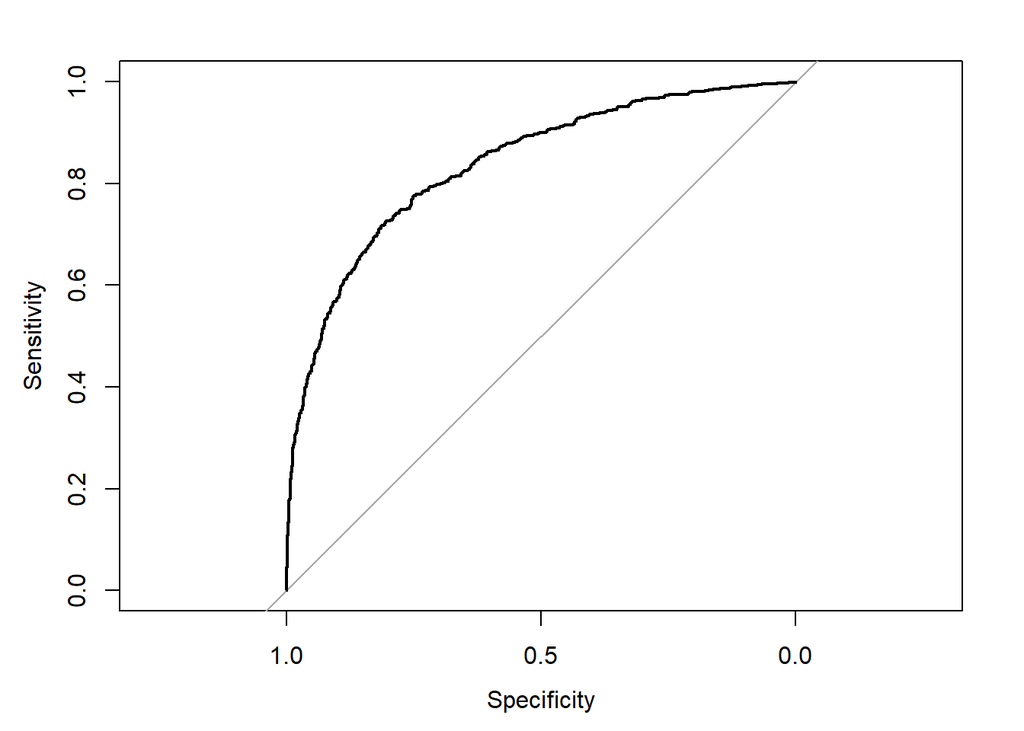

```r
plot(h)
```

The predictions on the unseen data were relatively solid, showing an accuracy of 78.8%, a noticeable increase in accuracy from just guessing the more popular classification. The AUC ended up at .837, which is above the .8 threshold that we look for, meaning the model was strong at distinguishing between classes. The ROC curve followed the trajectory that we expect from a good model, meaning it is much better at prediction than any sort of random guessing. The precision was 77.8%, meaning the model had solid accuracy when it predicted a movie to be above 6.3 rated. However, the recall rate was 53.8%, which meant the model was not fantastic at catching movies above 6.3, though when it did predict over 6.3 it was relatively accurate as shown by the precision. The specificity was 91.9%, meaning that the model was great at predicting movies rated below 6.3. I also predicted the training data to see if the model was possibly overfitting. However, all metrics were similar across the test and train data, and no performance drop was noticeable. This suggests that the model is not overfitting and can be a reliable predictor for whether or not a movie is rated above or below 6.3 on IMDb.

```r
library(rpart)
library(rpart.plot)

set.seed(852)

treefit = rpart(aboveavg ~ runtime + votes + action + horror + drama + romance + thriller + biography + war + scifi + history + fantasy + animation, data = datatrain, method = "class", control = list(maxdepth = 4))

summary(treefit)
```

```
## Call:
## rpart(formula = aboveavg ~ runtime + votes + action + horror +
##     drama + romance + thriller + biography + war + scifi + history +
##     fantasy + animation, data = datatrain, method = "class",
##     control = list(maxdepth = 4))
##   n= 9308
##
##       CP nsplit rel error xerror   xstd
## 1 0.2508      0     1.000  1.000 0.0140
## 2 0.0322      1     0.749  0.760 0.0130
## 3 0.0182      3     0.685  0.687 0.0126
## 4 0.0125      5     0.648  0.669 0.0125
## 5 0.0103      6     0.636  0.658 0.0124
## 6 0.0100      7     0.625  0.658 0.0124
##
## Variable importance
##     votes   runtime     drama animation    action    horror biography
##        61        22        10         2         2         1         1
##
## Node number 1: 9308 observations,    complexity param=0.251
##   predicted class=0  expected loss=0.353  P(node) =1
##     class counts:  6019  3289
##    probabilities: 0.647 0.353
##   left son=2 (6793 obs) right son=3 (2515 obs)
##   Primary splits:
##       votes     < 28300  to the left,  improve=665, (0 missing)
##       runtime   < 106    to the left,  improve=545, (0 missing)
##       drama     < 0.5    to the left,  improve=263, (0 missing)
##       biography < 0.5    to the left,  improve=212, (0 missing)
##       horror    < 0.5    to the right, improve=209, (0 missing)
##   Surrogate splits:
##       runtime < 120    to the left,  agree=0.761, adj=0.115, (0 split)
##
## Node number 2: 6793 observations,    complexity param=0.0182
##   predicted class=0  expected loss=0.238  P(node) =0.73
##     class counts:  5174  1619
##    probabilities: 0.762 0.238
##   left son=4 (5236 obs) right son=5 (1557 obs)
##   Primary splits:
##       runtime   < 104    to the left,  improve=187, (0 missing)
```

[output cut: 114 more lines]

```
##
## Node number 23: 639 observations
##   predicted class=1  expected loss=0.374  P(node) =0.0687
##     class counts:   239   400
##    probabilities: 0.374 0.626
##
## Node number 24: 674 observations
##   predicted class=0  expected loss=0.318  P(node) =0.0724
##     class counts:   460   214
##    probabilities: 0.682 0.318
##
## Node number 25: 88 observations
##   predicted class=1  expected loss=0.307  P(node) =0.00945
##     class counts:    27    61
##    probabilities: 0.307 0.693
```

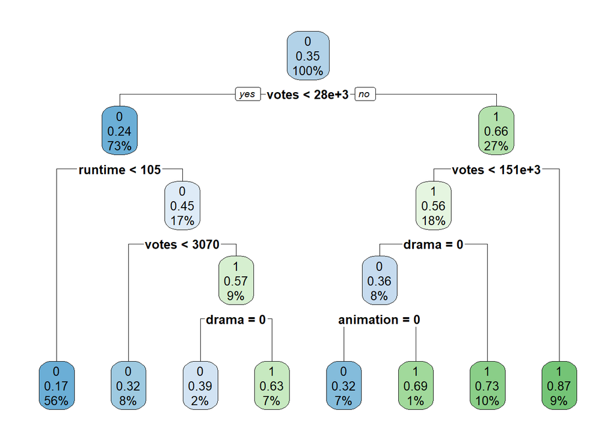

```r
rpart.plot(treefit)
```

With the logistic regression completed, I also wanted to try a decision/classification tree to possibly uncover any other patterns. The same formula and 80/20 train/test split were used, and a max of 4 levels of feature splits were implemented to minimize overfitting and variance.. Looking at the tree, we can see that the features chosen for the splits were number of votes, runtime, whether the movie was a drama, and whether the movie was an animated movie. Let’s examine the predictive power of the classification tree.

```r
#Test
treeprediction = predict(treefit, newdata = datatest, type = "class")
table(Predicted = treeprediction, Actual = datatest$aboveavg)
```

```
##          Actual
## Predicted    0    1
##         0 1390  356
##         1  137  445
```

```r
#Train
treeprediction2 = predict(treefit, newdata = datatrain, type = "class")
table(Predicted = treeprediction2, Actual = datatrain$aboveavg)
```

```
##          Actual
## Predicted    0    1
##         0 5395 1433
##         1  624 1856
```

```r
#Test
cm = confusionMatrix(treeprediction, reference = as.factor(datatest$aboveavg))
cm$overall
```

```
##       Accuracy          Kappa  AccuracyLower  AccuracyUpper   AccuracyNull
##       7.88e-01       4.98e-01       7.71e-01       8.05e-01       6.56e-01
## AccuracyPValue  McnemarPValue
##       1.28e-44       9.40e-23
```

```r
cm$byClass
```

```
##          Sensitivity          Specificity       Pos Pred Value
##                0.910                0.556                0.796
##       Neg Pred Value            Precision               Recall
##                0.765                0.796                0.910
##                   F1           Prevalence       Detection Rate
##                0.849                0.656                0.597
## Detection Prevalence    Balanced Accuracy
##                0.750                0.733
```

```r
#Train
cm2 = confusionMatrix(treeprediction2, reference = as.factor(datatrain$aboveavg))
cm2$overall
```

```
##       Accuracy          Kappa  AccuracyLower  AccuracyUpper   AccuracyNull
##       7.79e-01       4.88e-01       7.70e-01       7.87e-01       6.47e-01
## AccuracyPValue  McnemarPValue
##      1.51e-169       5.37e-71
```

```r
cm2$byClass
```

```
##          Sensitivity          Specificity       Pos Pred Value
##                0.896                0.564                0.790
##       Neg Pred Value            Precision               Recall
##                0.748                0.790                0.896
##                   F1           Prevalence       Detection Rate
##                0.840                0.647                0.580
## Detection Prevalence    Balanced Accuracy
##                0.734                0.730
```

Comparing the results for both the logistic regression and the classification tree, we can conclude that both models reliably predict whether a movie is above or below average (6.3 rated) on IMDb. While both models are accurate, each one has their drawbacks or tradeoffs from the other. Determining which model is better to use depends on if you want to minimize false negatives or minimize false positives. The logistic model predicted more false negatives, while the classification tree predicted more false positives. Regardless, both of these models met the criteria necessary to answer our question. Yes, we can reliably predict if a movie was rated above or below average on IMDb using genre, runtime, and number of votes.

# Question 3: How does the number of votes affect movie ratings after considering genre and release year?

Our third question is all about inference. We examine how the number of votes a movie receives affects its IMDB rating, while accounting for the movie’s release year and genre. The first step was visualizing how ratings differ across genres. The boxplot below shows that some genres consistently rate higher than others. Biography and Animation movies tend to have higher median ratings, while Horror movies have noticeably lower ratings. This variation in ratings by genre was a clear indication that we had to control for it. Additionally the correlation matrix below reveals that rating, votes, and year all have very weak relationships with each other. Rating and votes only have a correlation of 0.12, meaning votes alone do not predict ratings very well.

```r
#Importing Necessary Libraries
library(ezids)
library(ggplot2)
library(dplyr)
library(car)

action <- read.csv("action.csv")
adventure <- read.csv("adventure.csv")
animation <- read.csv("animation.csv")
biography <- read.csv("biography.csv")
crime <- read.csv("crime.csv")
family <- read.csv("family.csv")
fantasy <- read.csv("fantasy.csv")
noir <- read.csv("film-noir.csv")
history <- read.csv("history.csv")
horror <- read.csv("horror.csv")
mystery <- read.csv("mystery.csv")
romance <- read.csv("romance.csv")
scifi <- read.csv("scifi.csv")
sports <- read.csv("sports.csv")
thriller <- read.csv("thriller.csv")
war <- read.csv("war.csv")

action$genre <- "Action"
adventure$genre <- "Adventure"
animation$genre <- "Animation"
biography$genre <- "Biography"
crime$genre <- "Crime"
family$genre <- "Family"
fantasy$genre <- "Fantasy"
noir$genre <- "Film-Noir"
history$genre <- "History"
horror$genre <- "Horror"
mystery$genre <- "Mystery"
romance$genre <- "Romance"
scifi$genre <- "Sci-Fi"
sports$genre <- "Sports"
thriller$genre <- "Thriller"
war$genre <- "War"

action <- action[, c("movie_id", "year", "rating", "votes", "genre")]
adventure <- adventure[, c("movie_id", "year", "rating", "votes", "genre")]
animation <- animation[, c("movie_id", "year", "rating", "votes", "genre")]
biography <- biography[, c("movie_id", "year", "rating", "votes", "genre")]
crime <- crime[, c("movie_id", "year", "rating", "votes", "genre")]
family <- family[, c("movie_id", "year", "rating", "votes", "genre")]
fantasy <- fantasy[, c("movie_id", "year", "rating", "votes", "genre")]
noir <- noir[, c("movie_id", "year", "rating", "votes", "genre")]
history <- history[, c("movie_id", "year", "rating", "votes", "genre")]
horror <- horror[, c("movie_id", "year", "rating", "votes", "genre")]
mystery <- mystery[, c("movie_id", "year", "rating", "votes", "genre")]
romance <- romance[, c("movie_id", "year", "rating", "votes", "genre")]
scifi <- scifi[, c("movie_id", "year", "rating", "votes", "genre")]
sports <- sports[, c("movie_id", "year", "rating", "votes", "genre")]
thriller <- thriller[, c("movie_id", "year", "rating", "votes", "genre")]
war <- war[, c("movie_id", "year", "rating", "votes", "genre")]

allmovies <- rbind(action, adventure, animation, biography, crime,
                   family, fantasy, noir, history, horror,
                   mystery, romance, scifi, sports, thriller, war)


allmovies <- allmovies[!duplicated(allmovies$movie_id), ]

allmovies$year <- as.numeric(allmovies$year)
movies <- subset(allmovies, !is.na(rating) & !is.na(votes) & votes > 0 &
                 !is.na(year) & year >= 2000 & year <= 2023)

movies$genre <- as.factor(movies$genre)
```

[figure not shown]

```r
ggplot(movies, aes(x = reorder(genre, rating, median), y = rating, fill = genre)) +
  geom_boxplot() +
  labs(title = "Movie Ratings by Genre",
       x = "",
       y = "IMDB Rating") +
  theme_minimal()
```

```r
cor(movies[, c("rating", "votes", "year")])
```

```
##        rating   votes    year
## rating 1.0000  0.1205  0.0153
## votes  0.1205  1.0000 -0.0566
## year   0.0153 -0.0566  1.0000
```

We built three linear regression models starting simple and adding then increasing the number of regressors, model 1 only used votes as a regressor. Model 2 added the release year as a regressor, and model 3 added the genres as a regressor. We ensured that there was no multicollinearity by checking the VIF values for model 2 and 3, and used ANOVA to compare and assess the models in order to determine whether adding each new variable significantly improved the model.

```r
m1 <- lm(rating ~ votes, data = movies)
summary(m1)
```

```
##
## Call:
## lm(formula = rating ~ votes, data = movies)
##
## Residuals:
##    Min     1Q Median     3Q    Max
## -5.486 -0.936  0.065  0.965  4.265
##
## Coefficients:
##             Estimate Std. Error t value Pr(>|t|)
## (Intercept) 5.74e+00   5.38e-03  1066.0   <2e-16 ***
## votes       3.27e-06   9.83e-08    33.3   <2e-16 ***
## ---
## Signif. codes:  0 '***' 0.001 '**' 0.01 '*' 0.05 '.' 0.1 ' ' 1
##
## Residual standard error: 1.46 on 75130 degrees of freedom
## Multiple R-squared:  0.0145, Adjusted R-squared:  0.0145
## F-statistic: 1.11e+03 on 1 and 75130 DF,  p-value: <2e-16
```

Model 1 shows that votes alone have a statistically significant effect on ratings (p < 2e-16), although the effect is very small. The coefficient for votes is 0.00000327, this means that every additional 300,000 votes a movie receives its rating increases by 1 point. The R-squared is only 0.0145 so votes explain less than 1.5% of the variation in ratings.

```r
m2 <- lm(rating ~ votes + year, data = movies)
summary(m2)
```

```
##
## Call:
## lm(formula = rating ~ votes + year, data = movies)
##
## Residuals:
##    Min     1Q Median     3Q    Max
## -5.550 -0.947  0.102  0.982  4.234
##
## Coefficients:
##              Estimate Std. Error t value Pr(>|t|)
## (Intercept) -5.01e+00   1.76e+00   -2.85   0.0043 **
## votes        3.30e-06   9.84e-08   33.58  < 2e-16 ***
## year         5.34e-03   8.72e-04    6.12  9.4e-10 ***
## ---
## Signif. codes:  0 '***' 0.001 '**' 0.01 '*' 0.05 '.' 0.1 ' ' 1
##
## Residual standard error: 1.46 on 75129 degrees of freedom
## Multiple R-squared:  0.015,  Adjusted R-squared:  0.015
## F-statistic:  573 on 2 and 75129 DF,  p-value: <2e-16
```

```r
ezids::xkablevif(m2)
```

VIFs of Model: rating ~ votes + year

| votes | year |
| --- | --- |
| 1 | 1 |

Model 2 adds release year as a regressor and it is statistically significant (p = 9.4e-10) with a coefficient of 0.00534. So this means that every additional year you go up from 2000, the rating goes up by about 0.005 points. The votes coefficient barely moved from Model 1, and the R-squared only bumped up to 0.015. So the release year explains very little. The VIF values came in under 5, so multicollinearity is not a problem.

```r
m3 <- lm(rating ~ votes + year + genre, data = movies)
summary(m3)
```

```
##
## Call:
## lm(formula = rating ~ votes + year + genre, data = movies)
##
## Residuals:
##    Min     1Q Median     3Q    Max
## -5.806 -0.870  0.054  0.889  4.767
##
## Coefficients:
##                 Estimate Std. Error t value Pr(>|t|)
## (Intercept)    -1.38e+01   1.68e+00   -8.20  2.5e-16 ***
## votes           3.24e-06   9.40e-08   34.47  < 2e-16 ***
## year            9.62e-03   8.35e-04   11.53  < 2e-16 ***
## genreAdventure  2.64e-01   2.38e-02   11.06  < 2e-16 ***
## genreAnimation  6.24e-01   3.41e-02   18.27  < 2e-16 ***
## genreBiography  9.26e-01   3.12e-02   29.67  < 2e-16 ***
## genreCrime      3.66e-01   2.01e-02   18.19  < 2e-16 ***
## genreFamily     4.93e-01   2.49e-02   19.84  < 2e-16 ***
## genreFantasy    2.33e-01   2.81e-02    8.29  < 2e-16 ***
## genreHistory    8.67e-01   3.99e-02   21.72  < 2e-16 ***
## genreHorror    -7.66e-01   1.69e-02  -45.37  < 2e-16 ***
## genreMystery    4.13e-01   2.93e-02   14.08  < 2e-16 ***
## genreRomance    4.43e-01   1.66e-02   26.62  < 2e-16 ***
## genreSci-Fi    -1.11e-01   3.74e-02   -2.97    0.003 **
## genreSports     6.66e-01   5.22e-02   12.77  < 2e-16 ***
## genreThriller   1.77e-01   2.13e-02    8.30  < 2e-16 ***
## genreWar        7.38e-01   5.62e-02   13.14  < 2e-16 ***
## ---
## Signif. codes:  0 '***' 0.001 '**' 0.01 '*' 0.05 '.' 0.1 ' ' 1
##
## Residual standard error: 1.38 on 75115 degrees of freedom
## Multiple R-squared:  0.112,  Adjusted R-squared:  0.112
## F-statistic:  591 on 16 and 75115 DF,  p-value: <2e-16
```

```r
ezids::xkablevif(m3)
```

VIFs of Model: rating ~ votes + year + genre

| genreAdventure | genreAnimation | genreBiography | genreCrime | genreFamily | genreFantasy | genreHistory | genreHorror | genreMystery | genreRomance | genreSci-Fi | genreSports | genreThriller | genreWar | votes | year |
| --- | --- | --- | --- | --- | --- | --- | --- | --- | --- | --- | --- | --- | --- | --- | --- |
| 1.21 | 1.1 | 1.12 | 1.32 | 1.2 | 1.15 | 1.07 | 1.53 | 1.13 | 1.54 | 1.08 | 1.04 | 1.29 | 1.03 | 1.02 | 1.02 |

```r
anovares <- anova(m1, m2, m3)
anovares
```

```
## Analysis of Variance Table
##
## Model 1: rating ~ votes
## Model 2: rating ~ votes + year
## Model 3: rating ~ votes + year + genre
##   Res.Df    RSS Df Sum of Sq     F  Pr(>F)
## 1  75130 159466
## 2  75129 159387  1        79  41.5 1.2e-10 ***
## 3  75115 143713 14     15674 585.1 < 2e-16 ***
## ---
## Signif. codes:  0 '***' 0.001 '**' 0.01 '*' 0.05 '.' 0.1 ' ' 1
```

Overall the effects that votes and year have on ratings are statistically significant but practically meaningless. The unexpected realization is that a movie’s genre tells us much more about its likely rating than how many votes it received or even when it came out. Our third model only explains 11.2% of rating variation, and so about 88.8% of why movies get certain ratings remains unexplained. Other factors like budget, director, lead actors, and marketing likely matter a lot. Nevertheless the number of votes does affect movie ratings, but the effect is so small it barely matters. A movie would need hundreds of thousands of extra votes to move its rating by even one point. Genre and other unmeasured factors are more significant determinants of ratings.